# Examining the relationship between the big-5 personality facets and implicit racial attitudes

Analysis

Annika Langner

13 January, 2024

# Dependencies

```r
library(patchwork)
library(tidyverse)
library(knitr)
library(kableExtra)
library(ggplot2)
library(janitor)
library(scales)
library(cowplot)
library(ggExtra)
library(psych)
library(plyr)
library(dplyr)
library(stringr)
library(report)
library(cowplot)
```

# Data

- Exclude participants using the master exclusion variable

```r
#Load the processed data
data_processed <- read_csv("../data/processed/data_processed.csv")

#Exclude rows without unique_id --> exclude_unique_id_is.na
data_processed_without_unique_id <- data_processed |>
  filter(exclude_unique_id_is.na == "include")

#Exclude rows where participants have not participated in BFI and IAT
data_processed_BFI_IAT_answers <- data_processed |>
  filter(!is.na(exclude_bfi_completeness) & !is.na(exclude_iat_completeness))

#Exclude participants --> master exclusion variable
data_processed_after_exclusions <- data_processed |>
  filter(exclude_participant == "include")
```

# Sample descriptives

### Sample size before exclusions

- Create a table with the total number of participants before exclusions.

```r
cat("The question is 'what do you mean by total number of participants before exclusions'?\n Before any exclusion, there is the count of rows, which you can see in the next table (1968).")
```

```
## The question is 'what do you mean by total number of participants before exclusions'?
##  Before any exclusion, there is the count of rows, which you can see in the next table (1968).
```

```r
data_processed  %>%
  {data.frame(n = nrow(.))} %>%
  kable() %>%
  add_header_above(header = c("Whole sample" = 1)) %>%
  kable_classic(full_width = FALSE)
```

| Whole sample n |
| --- |
| 1968 |

```r
cat("However, there are also rows where no unique_id exists. Do these empty rows also represent participants, or should they be ignored? If ignored, the count would be 1932.")
```

```
## However, there are also rows where no unique_id exists. Do these empty rows also represent participants, or should they be ignored? If ignored, the count would be 1932.
```

```r
data_processed_without_unique_id %>%
  {data.frame(n = nrow(.))} %>%
  kable() %>%
  add_header_above(header = c("Whole sample with unique_id" = 1)) %>%
  kable_classic(full_width = FALSE)
```

| Whole sample with unique_id n |
| --- |
| 1932 |

```r
cat("And assuming that the demographic questions were only an option and the actual study revolves around IAT and BFI, could one argue that we only consider individuals who have answered at least one item in BFI and/or IAT? In that case, the count would be 179.->But here, I have already made exclusions.")
```

[output not shown]

```r
data_processed_BFI_IAT_answers %>%
  {data.frame(n = nrow(.))} %>%
  kable() %>%
  add_header_above(header = c("Whole sample with IAT and BFI answers" = 1)) %>%
  kable_classic(full_width = FALSE)
```

| Whole sample with IAT and BFI answers n |
| --- |
| 179 |

### Sample size after exclusions

- Create a table with the total number of participants after exclusions.

```r
data_processed_after_exclusions %>%
  {data.frame(n = nrow(.))} %>%
  kable() %>%
  add_header_above(header = c("For analysis" = 1)) %>%
  kable_classic(full_width = FALSE)
```

| For analysis n |
| --- |
| 161 |

### Age and Gender

- Create demographics tables that summarise the mean and SD age, and the frequency and percentage of men vs women in the sample. Report the proportion of participants for which each demographics variable was available.

Age

```r
data_processed_after_exclusions |>
  mutate(age = as.numeric(age)) |>
  summarise(Mean = mean(age, na.rm = TRUE),
            SD = sd(age, na.rm = TRUE)) |>
  mutate_all(.funs = janitor::round_half_up, digits = 1) |>
  kable() |>
  add_header_above(header = c("Age" = 2)) |>
  kable_classic(full_width = FALSE)
```

| Age Mean | Age SD |
| --- | --- |
| 30.6 | 11.3 |

```r
#Information about age = NA
count_na_age_number <- sum(!is.na(data_processed_after_exclusions$age))
count_na_age_proprtion<-round((nrow(data_processed_after_exclusions)-sum(is.na(data_processed_after_exclusions$age)))/nrow(data_processed_after_exclusions),2)
cat(count_na_age_number, "person(s) reported age.\n The proportion of participants for which the age variable was available is",count_na_age_proprtion,".")
```

```
## 139 person(s) reported age.
##  The proportion of participants for which the age variable was available is 0.86 .
```

Gender

```r
cat("Table with NA")
```

```
## Table with NA
```

```r
gender<-data_processed_after_exclusions$gender|>
  count()

colnames(gender)[colnames(gender) == "x"] <- "Gender"
colnames(gender)[colnames(gender) == "freq"] <- "n"
gender<-gender|>mutate(Gender = case_when(Gender == "f" ~ "Female",
                                          Gender == "m" ~ "Male"),
                       percent = paste0(round_half_up((n / sum(n)) * 100, 1), "%"))
table_gender <- gender |>
  kable() |>
  kable_classic(full_width = FALSE)
table_gender
```

| Gender | n | percent |
| --- | --- | --- |
| Female | 86 | 53.4% |
| Male | 53 | 32.9% |
| NA | 22 | 13.7% |

```r
cat("Table of men vs women, without NA")
```

```
## Table of men vs women, without NA
```

```r
gender<-data_processed_after_exclusions$gender|>
  count()|>
  filter(x=="f"|x=="m")

colnames(gender)[colnames(gender) == "x"] <- "Gender"
colnames(gender)[colnames(gender) == "freq"] <- "n"
gender<-gender|>mutate(Gender = case_when(Gender == "f" ~ "Female",
                                          Gender == "m" ~ "Male"),
                       percent = paste0(round_half_up((n / sum(n)) * 100, 1), "%"))

table_gender <- gender |>
  kable() |>
  kable_classic(full_width = FALSE)
table_gender
```

| Gender | n | percent |
| --- | --- | --- |
| Female | 86 | 61.9% |
| Male | 53 | 38.1% |

```r
#another way to create a gender table
#data_processed_after_exclusions|>
#  rename(Gender=gender)|>
#  group_by(Gender)|>
#  summarise(n=n())|>
#  mutate(Percent=paste()(round_half_up((n/sum(n))*100,1),"%"))|>
#  mutate(Gender=stringr::str_to_sentence(Gender))|>
#  kable()|>
#  kable_classic(full_width=FALSE)

#Information about gender = NA
count_na_gender_number <- sum(!is.na(data_processed_after_exclusions$gender))
count_na_gender_proprtion<-round((nrow(data_processed_after_exclusions)-sum(is.na(data_processed_after_exclusions$gender)))/nrow(data_processed_after_exclusions),2)
cat(count_na_gender_number, "person(s) reported gender.\n The proportion of participants for which the age variable was available is",count_na_gender_proprtion,".")
```

[output not shown]

# Descriptives statistics

### Cronbach’s alpha

- Calculate Cronbach’s alpha for each of the BFI subscales.

```r
#Select necessary columns
data_alpha_e <- data_processed_after_exclusions |>
  select(starts_with("bfi_e")) |>
  select(-bfi_e_mean)

data_alpha_c <- data_processed_after_exclusions |>
  select(starts_with("bfi_c")) |>
  select(-bfi_c_mean)

data_alpha_n <- data_processed_after_exclusions |>
  select(starts_with("bfi_n")) |>
  select(-bfi_n_mean)

data_alpha_a <- data_processed_after_exclusions |>
  select(starts_with("bfi_a")) |>
  select(-bfi_a_mean)

data_alpha_o <- data_processed_after_exclusions |>
  select(starts_with("bfi_o")) |>
  select(-bfi_o_mean)

#Determine alpha values
alpha_e <- alpha( data_alpha_e, na.rm = TRUE)
alpha_c <- alpha( data_alpha_c, na.rm = TRUE)
alpha_n <- alpha( data_alpha_n, na.rm = TRUE)
alpha_a <- alpha( data_alpha_a, na.rm = TRUE)
alpha_o <- alpha( data_alpha_o, na.rm = TRUE)

cat("Cronbach's alpha for the subscales:\n
    extroversion:", round(alpha_e$total$raw_alpha,2), "\n
    conscientiousness:",round( alpha_c$total$raw_alpha,2), "\n
    neuroticism:", round(alpha_n$total$raw_alpha,2), "\n
    agreeableness:", round(alpha_a$total$raw_alpha,2), "\n
    openness:", round(alpha_o$total$raw_alpha,2), "\n")
```

```
## Cronbach's alpha for the subscales:
##
##     extroversion: 0.82
##
##     conscientiousness: 0.81
##
##     neuroticism: 0.78
##
##     agreeableness: 0.78
##
##     openness: 0.81
```

### Histograms

- Create series of histograms of the distribution of scores on each of the BFI subscales and the IAT.

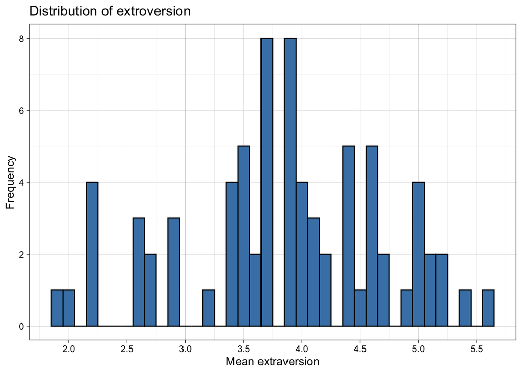

```r
#extroversion
ggplot(data_processed_after_exclusions, aes(x = bfi_e_mean))+
  geom_histogram(binwidth = 0.1,
                 fill = "steelblue",
                 color = "black") +
  labs(title="Distribution of extroversion ",x="Mean extraversion",y="Frequency")+
  theme_linedraw() +
  scale_x_continuous(breaks = pretty_breaks(n = 10))
```

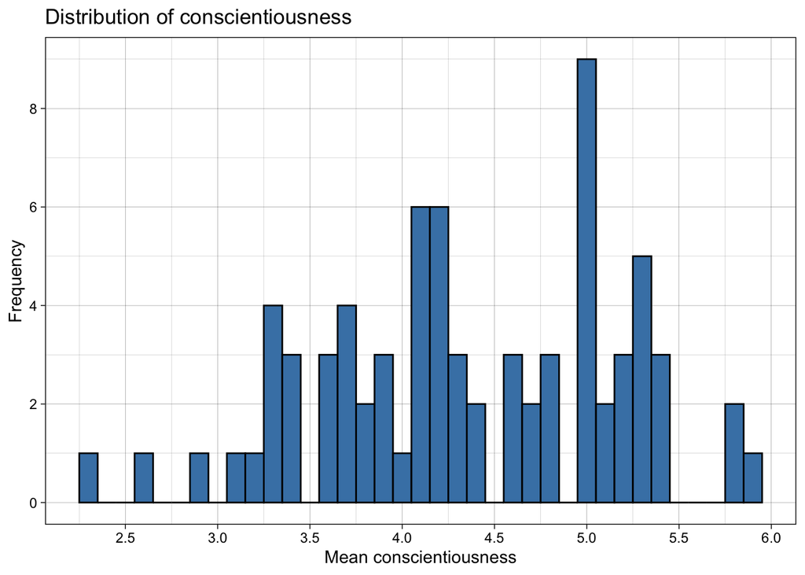

```r
#conscientiousness
ggplot(data_processed_after_exclusions, aes(x = bfi_c_mean)) +
  geom_histogram(binwidth = 0.1,
                 fill = "steelblue",
                 color = "black") +
  labs(title="Distribution of conscientiousness ",x="Mean conscientiousness",y="Frequency")+
  theme_linedraw() +
  scale_x_continuous(breaks = pretty_breaks(n = 10)) +
  scale_y_continuous(breaks = seq(0, 10, by = 2),
                     labels = as.character(seq(0, 10, by = 2)))
```

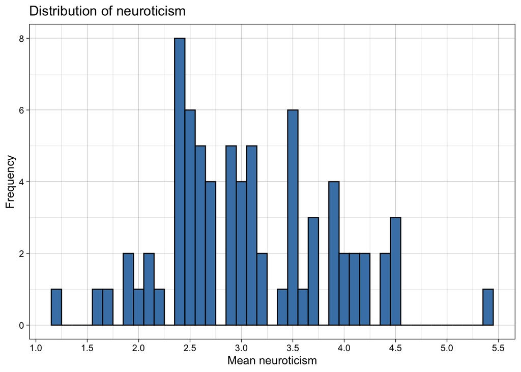

```r
#neuroticism
ggplot(data_processed_after_exclusions, aes(x = bfi_n_mean)) +
  geom_histogram(binwidth = 0.1,
                 fill = "steelblue",
                 color = "black") +
  labs(title="Distribution of neuroticism",x="Mean neuroticism",y="Frequency")+
  theme_linedraw() +
  scale_x_continuous(breaks = pretty_breaks(n = 10))
```

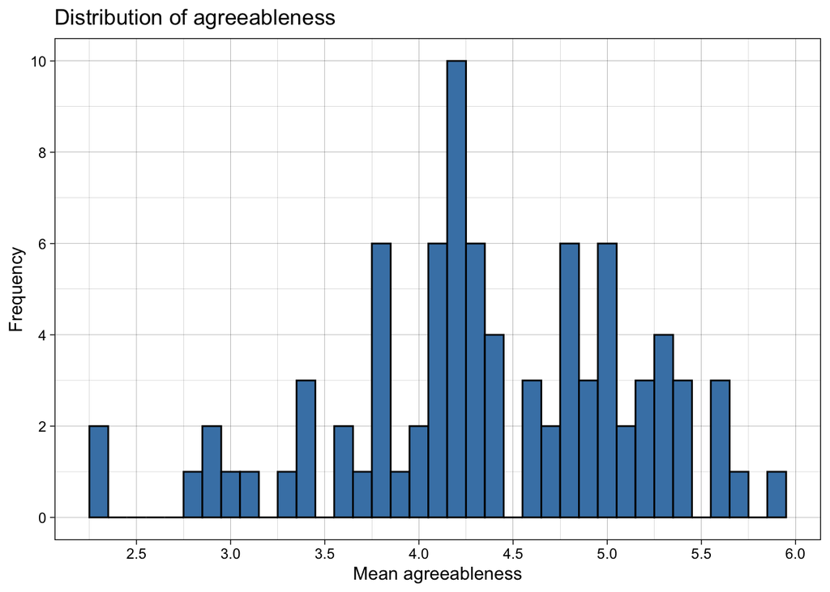

```r
#agreeableness
ggplot(data_processed_after_exclusions, aes(x = bfi_a_mean)) +
  geom_histogram(binwidth = 0.1,
                 fill = "steelblue",
                 color = "black") +
  labs(title="Distribution of agreeableness",x="Mean agreeableness",y="Frequency")+
  theme_linedraw() +
  scale_x_continuous(breaks = pretty_breaks(n = 10))+
  scale_y_continuous(breaks = seq(0, 10, by = 2),
                     labels = as.character(seq(0, 10, by = 2)))
```

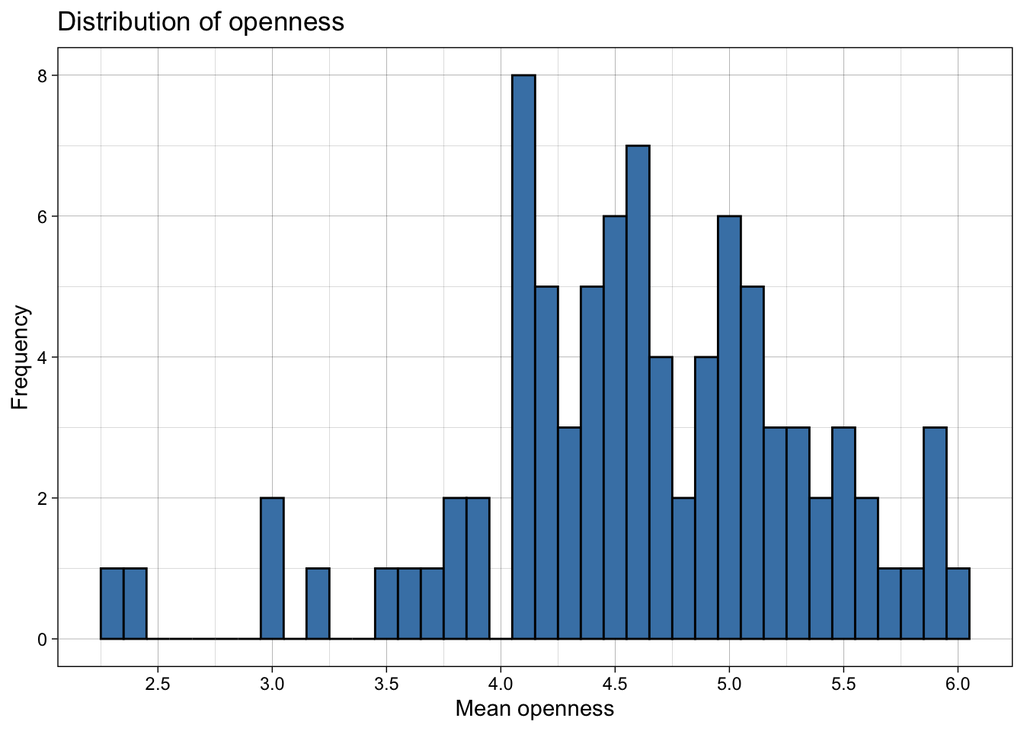

```r
#openness
ggplot(data_processed_after_exclusions, aes(x = bfi_o_mean)) +
  geom_histogram(binwidth = 0.1,
                 fill = "steelblue",
                 color = "black") +
  labs(title="Distribution of openness",x="Mean openness",y="Frequency")+
  theme_linedraw() +
  scale_x_continuous(breaks = pretty_breaks(n = 10))
```

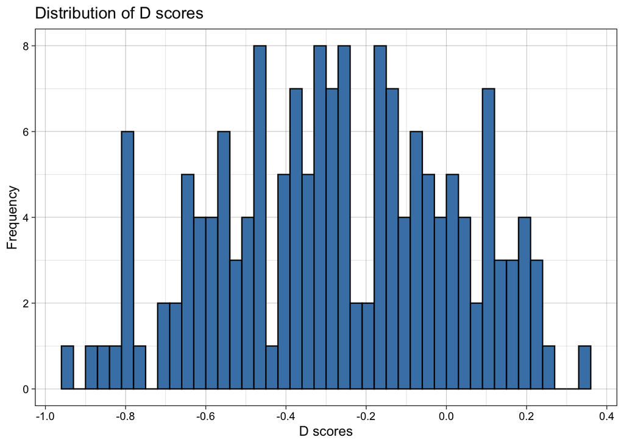

```r
#IAT
ggplot(data_processed_after_exclusions, aes(x = iat_D)) +
  geom_histogram(binwidth = 0.03,
                 boundary = 0,
                 fill = "steelblue",
                 color = "black") +
  labs(title="Distribution of D scores",x="D scores",y="Frequency")+
  theme_linedraw() +
  scale_x_continuous(breaks = pretty_breaks(n = 10))
```

# Inferential statistics

### Correlation matrix

- Create a table with a correlation matrix of the Pearson’s r correlations between the IAT and the BFI subscales rounded to two decimal places.

```r
detach("package:plyr", unload = TRUE)
library(dplyr)

# Rename column names for better readability in the table
data_processed_after_exclusions_newname <- data_processed_after_exclusions %>%
  rename(extraversion = bfi_e_mean,
         openness=bfi_o_mean,
         neuroticism=bfi_n_mean,
         conscientiousness=bfi_c_mean,
         agreeableness=bfi_a_mean,
         D=iat_D,
  )

#Create correlation table
data_processed_after_exclusions_newname |>
  select(D, extraversion, conscientiousness, neuroticism, agreeableness, openness) |>
  cor(method = "pearson", use = "pairwise.complete.obs")|>
  round(2)|>
  kable() |>
  kable_classic(full_width = FALSE)|>
  add_header_above(header = c("Correlations between BFI scales and IAT score D" = 7),  align = "left")
```

| Correlations between BFI scales and IAT score D | Correlations between BFI scales and IAT score D D | Correlations between BFI scales and IAT score D extraversion | Correlations between BFI scales and IAT score D conscientiousness | Correlations between BFI scales and IAT score D neuroticism | Correlations between BFI scales and IAT score D agreeableness | Correlations between BFI scales and IAT score D openness |
| --- | --- | --- | --- | --- | --- | --- |
| D | 1.00 | 0.10 | -0.07 | 0.07 | -0.05 | -0.01 |
| extraversion | 0.10 | 1.00 | 0.09 | -0.10 | NA | NA |
| conscientiousness | -0.07 | 0.09 | 1.00 | -0.33 | NA | NA |
| neuroticism | 0.07 | -0.10 | -0.33 | 1.00 | NA | NA |
| agreeableness | -0.05 | NA | NA | NA | 1.00 | 0.14 |
| openness | -0.01 | NA | NA | NA | 0.14 | 1.00 |

### t-test

- Run a t-test to test the hypothesis that men and women differ on their scores on the IAT. Report and interpret the results using {report}.

```r
# Check if it is normally distributed
shapiro_test <- shapiro.test(data_processed_after_exclusions$iat_D)

#  Print the result of shapiro test. Check the p-value against the chosen significance level (e.g., 0.05)
if (shapiro_test$p.value < 0.05) {
  cat("The data is not normally distributed based on the Shapiro-Wilk test (p-value=", round(shapiro_test$p.value,2),").")
} else {
  cat("The data appears to be normally distributed based on the Shapiro-Wilk test (p-value=", round(shapiro_test$p.value,2),").")
}
```

```
## The data appears to be normally distributed based on the Shapiro-Wilk test (p-value= 0.07 ).
```

```r
#t-test
t_test_result <- t.test(iat_D ~ gender, data = data_processed_after_exclusions)

#Print results in various formats
report(t_test_result)
```

```
## Effect sizes were labelled following Cohen's (1988) recommendations.
##
## The Welch Two Sample t-test testing the difference of iat_D by gender (mean in
## group f = -0.25, mean in group m = -0.28) suggests that the effect is positive,
## statistically not significant, and very small (difference = 0.04, 95% CI
## [-0.06, 0.14], t(111.55) = 0.77, p = 0.442; Cohen's d = 0.15, 95% CI [-0.23,
## 0.52])
```

```r
if (t_test_result$p.value < 0.05) {
  cat("Men and women differ on their scores on the IAT (p-value:", round(t_test_result$p.value,2),").")
} else {
  cat("Men and women don't differ on their scores on the IAT (p-value:", round(t_test_result$p.value,2),").")
}
```

```
## Men and women don't differ on their scores on the IAT (p-value: 0.44 ).
```

```r
cat("t-Test Results:\n Test Statistic:", t_test_result$statistic, "\n Degrees of Freedom:", t_test_result$parameter, "\n Mean Difference:", mean(data_processed_after_exclusions$iat_scores[data_processed_after_exclusions$sex == "Male"], na.rm = TRUE) -
    mean(data_processed_after_exclusions$iat_scores[data_processed_after_exclusions$sex == "Female"], na.rm = TRUE))
```

```
## t-Test Results:
##  Test Statistic: 0.7715607
##  Degrees of Freedom: 111.5517
##  Mean Difference: NA
```

### Regression

- Run a series of regressions to test the hypotheses that each BFI subscale predicts IAT scores. Run separate regressions for each subscale rather than a multiple regression. Report and interpret the results using {report}.

Extroversion

```r
reg_model_e <- lm(iat_D ~ bfi_e_mean, data = data_processed_after_exclusions)
report(reg_model_e)
```

```
## We fitted a linear model (estimated using OLS) to predict iat_D with bfi_e_mean
## (formula: iat_D ~ bfi_e_mean). The model explains a statistically not
## significant and very weak proportion of variance (R2 = 0.01, F(1, 73) = 0.77, p
## = 0.383, adj. R2 = -3.11e-03). The model's intercept, corresponding to
## bfi_e_mean = 0, is at -0.41 (95% CI [-0.71, -0.11], t(73) = -2.71, p = 0.008).
## Within this model:
##
##   - The effect of bfi e mean is statistically non-significant and positive (beta
## = 0.03, 95% CI [-0.04, 0.11], t(73) = 0.88, p = 0.383; Std. beta = 0.10, 95% CI
## [-0.13, 0.33])
##
## Standardized parameters were obtained by fitting the model on a standardized
## version of the dataset. 95% Confidence Intervals (CIs) and p-values were
## computed using a Wald t-distribution approximation.
```

```r
#Additional information and options for reporting the results. Not necessary for this task.
summary(reg_model_e)
```

```
##
## Call:
## lm(formula = iat_D ~ bfi_e_mean, data = data_processed_after_exclusions)
##
## Residuals:
##      Min       1Q   Median       3Q      Max
## -0.69260 -0.23323  0.00963  0.20017  0.53671
##
## Coefficients:
##             Estimate Std. Error t value Pr(>|t|)
## (Intercept) -0.41147    0.15158  -2.714  0.00828 **
## bfi_e_mean   0.03361    0.03828   0.878  0.38292
## ---
## Signif. codes:  0 '***' 0.001 '**' 0.01 '*' 0.05 '.' 0.1 ' ' 1
##
## Residual standard error: 0.285 on 73 degrees of freedom
##   (86 observations deleted due to missingness)
## Multiple R-squared:  0.01045,    Adjusted R-squared:  -0.00311
## F-statistic: 0.7706 on 1 and 73 DF,  p-value: 0.3829
```

```r
reg_model_e_sum <- lm(iat_D ~ bfi_e_mean, data = data_processed_after_exclusions)|>summary()
p_value_e <- reg_model_e_sum$coefficients["bfi_e_mean", "Pr(>|t|)"]

if (p_value_e < 0.05) {
  cat("EXTROVERSION: The regression indicates that the relationship between bfi_e_mean and iat_D is statistically significant (p =", round(p_value_e,2), "). This suggests that extroversion has a significant impact on IAT scores.\n
      Full results from the regression analysis for extraversion (bfi_e_mean) and IAT scores (iat_D) are presented in the following table.")
} else {
  cat("EXTROVERSION: The regression does not provide evidence of a statistically significant relationship between extroversion and IAT scores (p =",round( p_value_e,2), ").\n
      Full results from the regression analysis for extraversion (bfi_e_mean) and IAT scores (iat_D) are presented in the following table.")
}
```

[output not shown]

Conscientiousness

```r
reg_model_c <- lm(iat_D ~ bfi_c_mean, data = data_processed_after_exclusions)
report(reg_model_c)
```

```
## We fitted a linear model (estimated using OLS) to predict iat_D with bfi_c_mean
## (formula: iat_D ~ bfi_c_mean). The model explains a statistically not
## significant and very weak proportion of variance (R2 = 4.53e-03, F(1, 73) =
## 0.33, p = 0.566, adj. R2 = -9.11e-03). The model's intercept, corresponding to
## bfi_c_mean = 0, is at -0.18 (95% CI [-0.54, 0.19], t(73) = -0.96, p = 0.338).
## Within this model:
##
##   - The effect of bfi c mean is statistically non-significant and negative (beta
## = -0.02, 95% CI [-0.11, 0.06], t(73) = -0.58, p = 0.566; Std. beta = -0.07, 95%
## CI [-0.30, 0.17])
##
## Standardized parameters were obtained by fitting the model on a standardized
## version of the dataset. 95% Confidence Intervals (CIs) and p-values were
## computed using a Wald t-distribution approximation.
```

```r
summary(reg_model_c)
```

```
##
## Call:
## lm(formula = iat_D ~ bfi_c_mean, data = data_processed_after_exclusions)
##
## Residuals:
##      Min       1Q   Median       3Q      Max
## -0.68095 -0.20746  0.01326  0.20478  0.51965
##
## Coefficients:
##             Estimate Std. Error t value Pr(>|t|)
## (Intercept) -0.17737    0.18388  -0.965    0.338
## bfi_c_mean  -0.02391    0.04150  -0.576    0.566
##
## Residual standard error: 0.2859 on 73 degrees of freedom
##   (86 observations deleted due to missingness)
## Multiple R-squared:  0.004526,   Adjusted R-squared:  -0.009111
## F-statistic: 0.3319 on 1 and 73 DF,  p-value: 0.5663
```

```r
reg_model_c_sum <- lm(iat_D ~ bfi_c_mean,data = data_processed_after_exclusions)|>summary()
p_value_c <- reg_model_c_sum$coefficients["bfi_c_mean", "Pr(>|t|)"]

if (p_value_c < 0.05) {
  cat("CONSCIENTIOUSNESS: The regression indicates that the relationship between bfi_e_mean and iat_D is statistically significant (p =", round( p_value_c,2), "). This suggests that conscientiousness has a significant impact on IAT scores.\n
      Full results from the regression analysis for conscientiousness (bfi_c_mean) and IAT scores (iat_D) are presented in the following table.")
} else {
  cat("CONSCIENTIOUSNESS: The regression does not provide evidence of a statistically significant relationship between conscientiousness and IAT scores (p =",round( p_value_c,2), ").\n
       Full results from the regression analysis for conscientiousness (bfi_c_mean) and IAT scores (iat_D) are presented in the following table.")
}
```

[output not shown]

Neuroticism

```r
reg_model_n <- lm(iat_D ~ bfi_n_mean, data = data_processed_after_exclusions)
report(reg_model_n)
```

```
## We fitted a linear model (estimated using OLS) to predict iat_D with bfi_n_mean
## (formula: iat_D ~ bfi_n_mean). The model explains a statistically not
## significant and very weak proportion of variance (R2 = 5.08e-03, F(1, 73) =
## 0.37, p = 0.544, adj. R2 = -8.55e-03). The model's intercept, corresponding to
## bfi_n_mean = 0, is at -0.36 (95% CI [-0.62, -0.10], t(73) = -2.74, p = 0.008).
## Within this model:
##
##   - The effect of bfi n mean is statistically non-significant and positive (beta
## = 0.03, 95% CI [-0.06, 0.11], t(73) = 0.61, p = 0.544; Std. beta = 0.07, 95% CI
## [-0.16, 0.30])
##
## Standardized parameters were obtained by fitting the model on a standardized
## version of the dataset. 95% Confidence Intervals (CIs) and p-values were
## computed using a Wald t-distribution approximation.
```

```r
summary(reg_model_n)
```

```
##
## Call:
## lm(formula = iat_D ~ bfi_n_mean, data = data_processed_after_exclusions)
##
## Residuals:
##     Min      1Q  Median      3Q     Max
## -0.6872 -0.1983  0.0185  0.2105  0.4942
##
## Coefficients:
##             Estimate Std. Error t value Pr(>|t|)
## (Intercept) -0.35885    0.13083  -2.743  0.00766 **
## bfi_n_mean   0.02513    0.04117   0.610  0.54355
## ---
## Signif. codes:  0 '***' 0.001 '**' 0.01 '*' 0.05 '.' 0.1 ' ' 1
##
## Residual standard error: 0.2858 on 73 degrees of freedom
##   (86 observations deleted due to missingness)
## Multiple R-squared:  0.005077,   Adjusted R-squared:  -0.008553
## F-statistic: 0.3725 on 1 and 73 DF,  p-value: 0.5436
```

```r
reg_model_n_sum <- lm(iat_D ~ bfi_n_mean, data = data_processed_after_exclusions)|>summary()
p_value_n <- reg_model_n_sum$coefficients["bfi_n_mean", "Pr(>|t|)"]

if (p_value_n < 0.05) {
  cat("NEUROTICISM: The regression indicates that the relationship between bfi_e_mean and iat_D is statistically significant (p =", round( p_value_n,2), "). This suggests that neuroticism has a significant impact on IAT scores.\n
       Full results from the regression analysis for neuroticism (bfi_n_mean) and IAT scores (iat_D) are presented in the following table.")
} else {
  cat("NEUROTICISM: The regression does not provide evidence of a statistically significant relationship between neuroticism and IAT scores (p =", round( p_value_n,2), ").\n
       Full results from the regression analysis for neuroticism (bfi_n_mean) and IAT scores (iat_D) are presented in the following table.")
}
```

[output not shown]

Agreeableness

```r
reg_model_a <- lm(iat_D ~ bfi_a_mean, data = data_processed_after_exclusions)
report(reg_model_a)
```

```
## We fitted a linear model (estimated using OLS) to predict iat_D with bfi_a_mean
## (formula: iat_D ~ bfi_a_mean). The model explains a statistically not
## significant and very weak proportion of variance (R2 = 2.63e-03, F(1, 84) =
## 0.22, p = 0.639, adj. R2 = -9.25e-03). The model's intercept, corresponding to
## bfi_a_mean = 0, is at -0.18 (95% CI [-0.55, 0.19], t(84) = -0.96, p = 0.340).
## Within this model:
##
##   - The effect of bfi a mean is statistically non-significant and negative (beta
## = -0.02, 95% CI [-0.10, 0.06], t(84) = -0.47, p = 0.639; Std. beta = -0.05, 95%
## CI [-0.27, 0.17])
##
## Standardized parameters were obtained by fitting the model on a standardized
## version of the dataset. 95% Confidence Intervals (CIs) and p-values were
## computed using a Wald t-distribution approximation.
```

```r
summary(reg_model_a)
```

```
##
## Call:
## lm(formula = iat_D ~ bfi_a_mean, data = data_processed_after_exclusions)
##
## Residuals:
##      Min       1Q   Median       3Q      Max
## -0.62978 -0.21924 -0.01155  0.21828  0.59215
##
## Coefficients:
##             Estimate Std. Error t value Pr(>|t|)
## (Intercept)  -0.1796     0.1874  -0.959    0.340
## bfi_a_mean   -0.0198     0.0421  -0.470    0.639
##
## Residual standard error: 0.2992 on 84 degrees of freedom
##   (75 observations deleted due to missingness)
## Multiple R-squared:  0.002625,   Adjusted R-squared:  -0.009248
## F-statistic: 0.2211 on 1 and 84 DF,  p-value: 0.6394
```

```r
reg_model_a_sum <- lm(iat_D ~ bfi_a_mean, data= data_processed_after_exclusions)|>summary()
p_value_a <- reg_model_a_sum$coefficients["bfi_a_mean", "Pr(>|t|)"]

if (p_value_a < 0.05) {
  cat("AGREEABLENESS: The regression indicates that the relationship between bfi_e_mean and iat_D is statistically significant (p =", round( p_value_a,2), "). This suggests that agreeableness has a significant impact on IAT scores.\n
       Full results from the regression analysis for agreeableness (bfi_a_mean) and IAT scores (iat_D) are presented in the following table.")
} else {
  cat("AGREEABLENESS: The regression does not provide evidence of a statistically significant relationship between agreeableness and IAT scores (p =", round( p_value_a,2), ").\n
       Full results from the regression analysis for agreeableness (bfi_a_mean) and IAT scores (iat_D) are presented in the following table.")
}
```

[output not shown]

Openness

```r
reg_model_o <- lm(iat_D ~ bfi_o_mean, data = data_processed_after_exclusions)
report(reg_model_o)
```

```
## We fitted a linear model (estimated using OLS) to predict iat_D with bfi_o_mean
## (formula: iat_D ~ bfi_o_mean). The model explains a statistically not
## significant and very weak proportion of variance (R2 = 1.16e-04, F(1, 84) =
## 9.77e-03, p = 0.921, adj. R2 = -0.01). The model's intercept, corresponding to
## bfi_o_mean = 0, is at -0.25 (95% CI [-0.65, 0.16], t(84) = -1.20, p = 0.234).
## Within this model:
##
##   - The effect of bfi o mean is statistically non-significant and negative (beta
## = -4.35e-03, 95% CI [-0.09, 0.08], t(84) = -0.10, p = 0.921; Std. beta = -0.01,
## 95% CI [-0.23, 0.21])
##
## Standardized parameters were obtained by fitting the model on a standardized
## version of the dataset. 95% Confidence Intervals (CIs) and p-values were
## computed using a Wald t-distribution approximation.
```

```r
summary(reg_model_o)
```

```
##
## Call:
## lm(formula = iat_D ~ bfi_o_mean, data = data_processed_after_exclusions)
##
## Residuals:
##      Min       1Q   Median       3Q      Max
## -0.62618 -0.21453 -0.01605  0.22749  0.60411
##
## Coefficients:
##              Estimate Std. Error t value Pr(>|t|)
## (Intercept) -0.246401   0.205333  -1.200    0.234
## bfi_o_mean  -0.004345   0.043960  -0.099    0.921
##
## Residual standard error: 0.2996 on 84 degrees of freedom
##   (75 observations deleted due to missingness)
## Multiple R-squared:  0.0001163,  Adjusted R-squared:  -0.01179
## F-statistic: 0.009772 on 1 and 84 DF,  p-value: 0.9215
```

```r
reg_model_o_sum <- lm(iat_D ~ bfi_o_mean,data = data_processed_after_exclusions)|>summary()
p_value_o <- reg_model_o_sum$coefficients["bfi_o_mean", "Pr(>|t|)"]

if (p_value_o < 0.05) {
  cat("OPENNESS: The regression indicates that the relationship between bfi_e_mean and iat_D is statistically significant (p =", round( p_value_o,2), "). This suggests that openness has a significant impact on IAT scores.\n
       Full results from the regression analysis for openness (bfi_o_mean) and IAT scores (iat_D) are presented in the following table.")
} else {
  cat("OPENNESS: The regression does not provide evidence of a statistically significant relationship between openness and IAT scores (p =", round( p_value_o,2), ").\n
       Full results from the regression analysis for openness (bfi_o_mean) and IAT scores (iat_D) are presented in the following table.")
}
```

[output not shown]

### Scatter plots

- Create series of scatter plots of how BFI subscale scores predict IAT scores. Add regression lines. These plots therefore illustrate the same results as the regressions above. Make the plots presentable and publication quality- you may decide the details of this with one exception: Extreme scores on the IAT (defined as participants whose scores in the top and bottom 10% of IAT scores) should use a triangular shape rather than a dot.

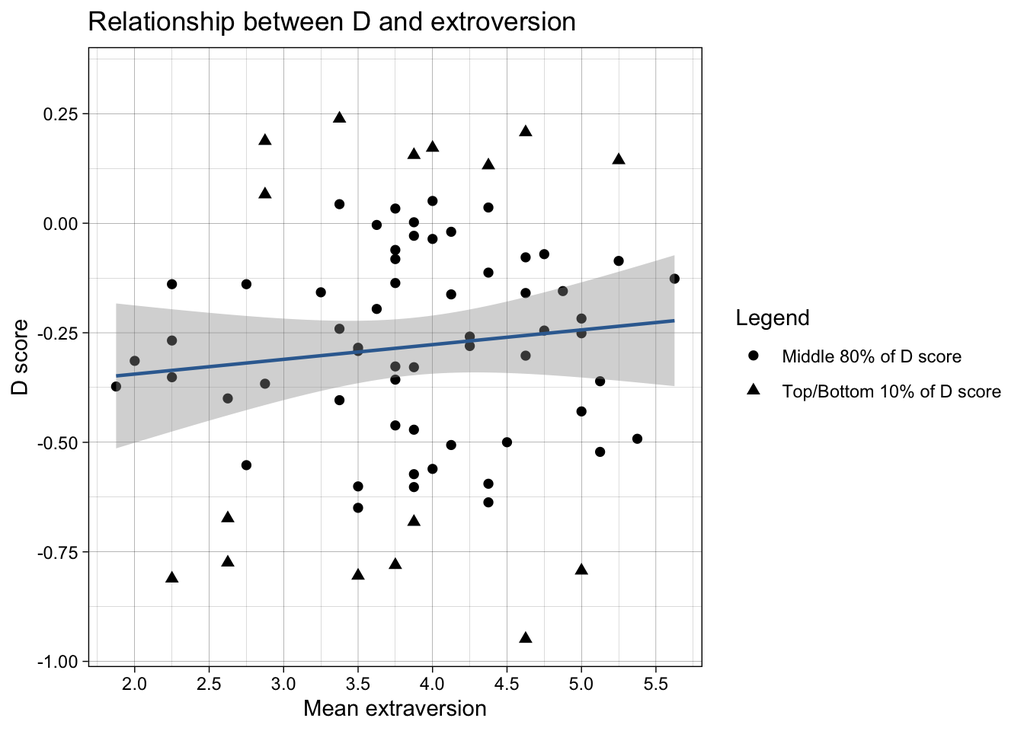

```r
#extroversion
data_processed_after_exclusions_e<-data_processed_after_exclusions|>
  filter(!is.na(bfi_e_mean))

x_threshold_low_e <- quantile(data_processed_after_exclusions_e$iat_D, 0.1)
x_threshold_high_e <- quantile(data_processed_after_exclusions_e$iat_D, 0.9)

scatterplot_e_single_plot<-ggplot(data_processed_after_exclusions, aes(x = bfi_e_mean, y = iat_D)) +
  geom_point(aes(shape = ifelse(iat_D >= x_threshold_high_e | iat_D <= x_threshold_low_e, "triangle", "circle")),
             size = 2,
             color = "black") +
  scale_shape_manual(values = c("triangle" = 17, "circle" = 16),
                     labels = c("triangle" = "Top/Bottom 10% of D score", "circle" = "Middle 80% of D score")) +
  geom_smooth(method = "lm", color = viridis_pal(begin = 0.45, option = "mako")(1), size = 0.8) +
  labs(title="Relationship between D and extroversion ",x="Mean extraversion",y="D score",shape = "Legend") +
  scale_y_continuous(breaks = c(-1,-.75, -0.5,-.25,0,0.25, 0.5))+
 scale_x_continuous(breaks = c(2,2.5,3,3.5,4,4.5,5,5.5,6))+
  theme_linedraw()

#conscientiousness
data_processed_after_exclusions_c<-data_processed_after_exclusions|>
  filter(!is.na(bfi_c_mean))

x_threshold_low_c <- quantile(data_processed_after_exclusions_c$iat_D, 0.1)
x_threshold_high_c <- quantile(data_processed_after_exclusions_c$iat_D, 0.9)

scatterplot_c_single_plot<-ggplot(data_processed_after_exclusions, aes(x = bfi_c_mean, y = iat_D)) +
  geom_point(aes(shape = ifelse(iat_D >= x_threshold_high_c | iat_D <= x_threshold_low_c, "triangle", "circle")),
             size = 2,
             color = "black") +
  scale_shape_manual(values = c("triangle" = 17, "circle" = 16),
                     labels = c("triangle" = "Top/Bottom 10% of D score", "circle" = "Middle 80% of D score")) +
  geom_smooth(method = "lm", color = viridis_pal(begin = 0.45, option = "mako")(1), size = 0.8) +
  labs(title="Relationship between D and conscientiousness ",x="Mean conscientiousness",y="D score",shape = "Legend") +
  scale_y_continuous(breaks = c(-1,-.75, -0.5,-.25,0,0.25, 0.5))+
 scale_x_continuous(breaks = c(2,2.5,3,3.5,4,4.5,5,5.5,6))+
  theme_linedraw()

#neuroticism
data_processed_after_exclusions_n<-data_processed_after_exclusions|>
  filter(!is.na(bfi_n_mean))

x_threshold_low_n <- quantile(data_processed_after_exclusions_n$iat_D, 0.1)
x_threshold_high_n <- quantile(data_processed_after_exclusions_n$iat_D, 0.9)

scatterplot_n_single_plot<-ggplot(data_processed_after_exclusions, aes(x = bfi_n_mean, y = iat_D)) +
  geom_point(aes(shape = ifelse(iat_D >= x_threshold_high_n | iat_D <= x_threshold_low_n, "triangle", "circle")),
             size = 2,
             color = "black") +
  scale_shape_manual(values = c("triangle" = 17, "circle" = 16),
                     labels = c("triangle" = "Top/Bottom 10% of D score", "circle" = "Middle 80% of D score")) +
  geom_smooth(method = "lm", color = viridis_pal(begin = 0.45, option = "mako")(1), size = 0.8) +
  labs(title="Relationship between D and neuroticism ",x="Mean neuroticism",y="D score",shape = "Legend") +
  scale_y_continuous(breaks = c(-1,-.75, -0.5,-.25,0,0.25, 0.5))+
  scale_x_continuous(breaks = c(1.5,2,2.5,3,3.5,4,4.5,5,5.5,6))+
  theme_linedraw()

#agreeableness
data_processed_after_exclusions_a<-data_processed_after_exclusions|>
  filter(!is.na(bfi_a_mean))

x_threshold_low_a <- quantile(data_processed_after_exclusions_a$iat_D, 0.1)
x_threshold_high_a <- quantile(data_processed_after_exclusions_a$iat_D, 0.9)

scatterplot_a_single_plot<-ggplot(data_processed_after_exclusions, aes(x = bfi_a_mean, y = iat_D)) +
  geom_point(aes(shape = ifelse(iat_D >= x_threshold_high_a | iat_D <= x_threshold_low_a, "triangle", "circle")),
             size = 2,
             color = "black") +
  scale_shape_manual(values = c("triangle" = 17, "circle" = 16),
                     labels = c("triangle" = "Top/Bottom 10% of D score", "circle" = "Middle 80% of D score")) +
  geom_smooth(method = "lm", color = viridis_pal(begin = 0.45, option = "mako")(1), size = 0.8) +
  labs(title="Relationship between D and agreeableness ",x="Mean agreeableness",y="D score",shape = "Legend") +
  scale_y_continuous(breaks = c(-1,-.75, -0.5,-.25,0,0.25, 0.5))+
  scale_x_continuous(breaks = c(2,2.5,3,3.5,4,4.5,5,5.5,6))+
  theme_linedraw()

#openness
data_processed_after_exclusions_o<-data_processed_after_exclusions|>
  filter(!is.na(bfi_o_mean))

x_threshold_low_o <- quantile(data_processed_after_exclusions_o$iat_D, 0.1)
x_threshold_high_o <- quantile(data_processed_after_exclusions_o$iat_D, 0.9)

scatterplot_o_single_plot<-ggplot(data_processed_after_exclusions, aes(x = bfi_o_mean, y = iat_D)) +
  geom_point(aes(shape = ifelse(iat_D >= x_threshold_high_o | iat_D <= x_threshold_low_o, "triangle", "circle")),
             size = 2,
             color = "black") +
  scale_shape_manual(values = c("triangle" = 17, "circle" = 16),
                     labels = c("triangle" = "Top/Bottom 10% of D score", "circle" = "Middle 80% of D score")) +
  geom_smooth(method = "lm", color = viridis_pal(begin = 0.45, option = "mako")(1), size = 0.8) +
  xlab("Mean openness") +
  ylab("D score") +
  labs(title="Relationship between D and openness",x="Mean openness",y="D score",shape = "Legend") +
  scale_y_continuous(breaks = c(-1,-.75, -0.5,-.25,0,0.25, 0.5))+
  scale_x_continuous(breaks = c(2,2.5,3,3.5,4,4.5,5,5.5,6))+
  theme_linedraw()

scatterplot_e_single_plot
```

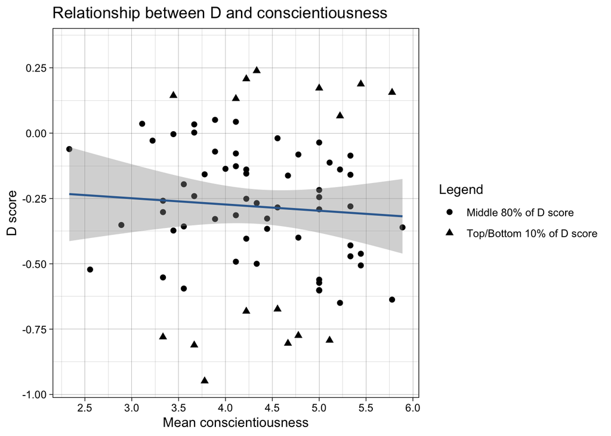

```r
scatterplot_c_single_plot
```

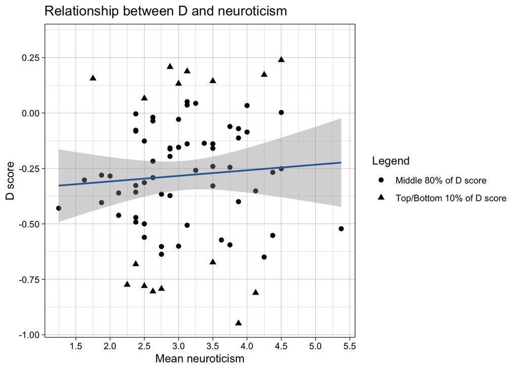

```r
scatterplot_n_single_plot
```

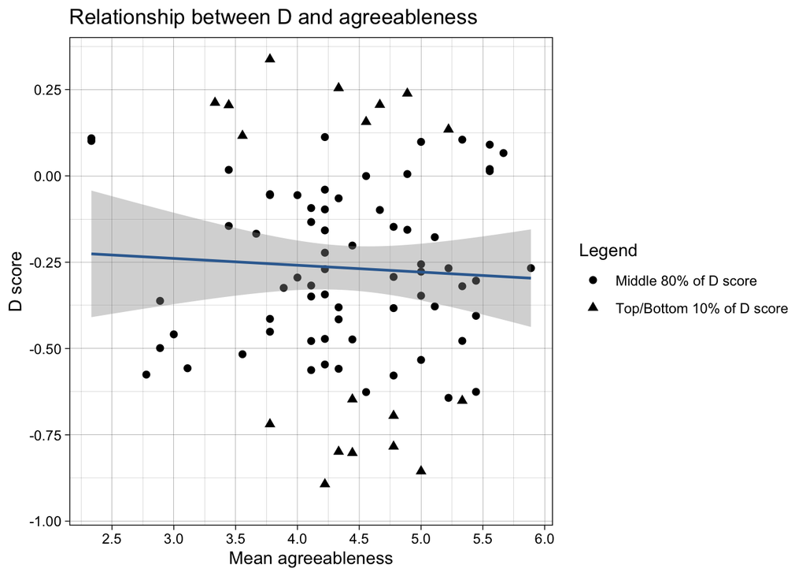

```r
scatterplot_a_single_plot
```

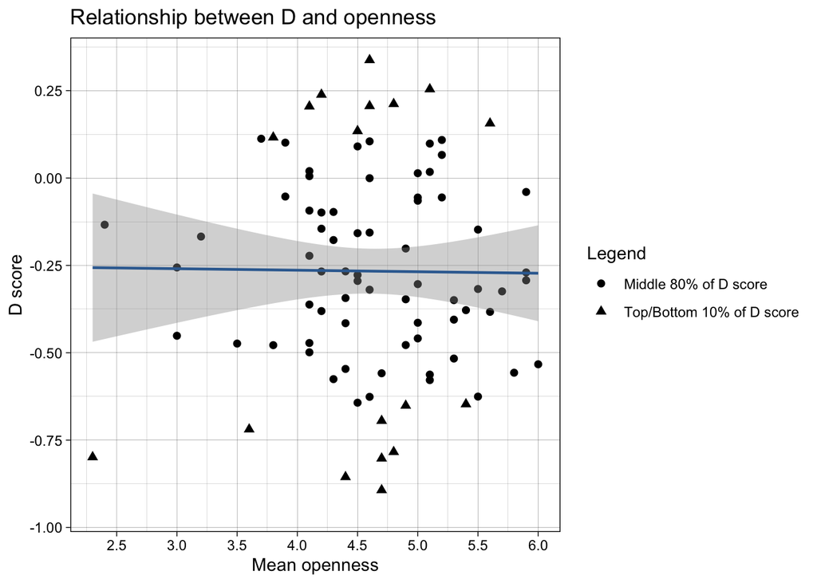

```r
scatterplot_o_single_plot
```

### Combined plot

I ajusted plots for combined plot

```r
cat("I have adjusted the plots again to enhance their visual appearance in the combined plot (modifying the axis labels, making points smaller )")
```

```
## I have adjusted the plots again to enhance their visual appearance in the combined plot (modifying the axis labels, making points smaller )
```

```r
cat("In the task, it is mentioned that personality traits should be clearly labeled. I find that using the X-axis is sufficient. There should be no misunderstanding, but if you meant to add a title above the plots, then this is the code that should have been added.+labs(title=Personality trait), Personality trait must be in quotation marks")
```

[output not shown]

```r
# Below, the plots have been recreated.

#extraversion
scatterplot_e<-ggplot(data_processed_after_exclusions, aes(x = bfi_e_mean, y = iat_D)) +
  geom_point(aes(shape = ifelse(iat_D > x_threshold_high_e | iat_D < x_threshold_low_e, "triangle", "circle")),
             size = 1,
             color = "black") +
  scale_shape_manual(values = c("triangle" = 17, "circle" = 16),
                     labels = c("triangle" = "Top/Bottom 10% of D score", "circle" = "Middle 80% of D score")) +
  geom_smooth(method = "lm", color = viridis_pal(begin = 0.45, option = "mako")(1), size = 0.7) +
  xlab("Mean extraversion") +
  ylab("D score") +
  theme_linedraw()+
  theme(legend.position="none")

#conscientiousness
scatterplot_c<-ggplot(data_processed_after_exclusions, aes(x = bfi_c_mean, y = iat_D)) +
  geom_point(aes(shape = ifelse(iat_D > x_threshold_high_c | iat_D < x_threshold_low_c, "triangle", "circle")),
             size = 1,
             color = "black") +
  scale_shape_manual(values = c("triangle" = 17, "circle" = 16),
                     labels = c("triangle" = "Top/Bottom 10% of D score", "circle" = "Middle 80% of D score")) +
  geom_smooth(method = "lm", color = viridis_pal(begin = 0.45, option = "mako")(1), size = 0.7) +
  xlab("Mean conscientiousness") +
  ylab("D score") +
  theme_linedraw()+
  theme(legend.position="none")

#neuroticism
scatterplot_n<-ggplot(data_processed_after_exclusions, aes(x = bfi_n_mean, y = iat_D)) +
  geom_point(aes(shape = ifelse(iat_D > x_threshold_high_n | iat_D < x_threshold_low_n, "triangle", "circle")),
             size = 1,
             color = "black") +
  scale_shape_manual(values = c("triangle" = 17, "circle" = 16),
                     labels = c("triangle" = "Top/Bottom 10% of D score", "circle" = "Middle 80% of D score"),
                     name = "Legend")+
  geom_smooth(method = "lm", color = viridis_pal(begin = 0.45, option = "mako")(1), size = 0.7) +
  xlab("Mean neuroticism") +
  ylab("D score") +
  theme_linedraw()

#agreeableness
scatterplot_a<-ggplot(data_processed_after_exclusions, aes(x = bfi_a_mean, y = iat_D)) +
  geom_point(aes(shape = ifelse(iat_D > x_threshold_high_a | iat_D < x_threshold_low_a, "triangle", "circle")),
             size = 1,
             color = "black") +
  scale_shape_manual(values = c("triangle" = 17, "circle" = 16),
                     labels = c("triangle" = "Top/Bottom 10% of D score", "circle" = "Middle 80% of D score")) +
  geom_smooth(method = "lm", color = viridis_pal(begin = 0.45, option = "mako")(1), size = 0.7) +
  xlab("Mean agreeableness") +
  ylab("D score") +
  theme_linedraw()+
  theme(legend.position="none")

#openness
scatterplot_o<-ggplot(data_processed_after_exclusions, aes(x = bfi_o_mean, y = iat_D)) +
  geom_point(aes(shape = ifelse(iat_D > x_threshold_high_o | iat_D < x_threshold_low_o, "triangle", "circle")),
             size = 1,
             color = "black") +
  scale_shape_manual(values = c("triangle" = 17, "circle" = 16),
                     labels = c("triangle" = "Top/Bottom 10% of D score", "circle" = "Middle 80% of D score")) +
  geom_smooth(method = "lm", color = viridis_pal(begin = 0.45, option = "mako")(1), size = 0.7) +
  xlab("Mean openness") +
  ylab("D score") +
  theme_linedraw()+
  theme(legend.position="none")
```

- A single combined plot should be created, containing 5 component plots, with the personality facet being examined in each clearly labelled. This plot should be printed in the html file but also saved to disk as both png/pdf.
- Combine these scatter plots into one ggplot object using {patchwork} and print the combined plot in your .Rmd and .html. Save the combined plot to disk as a .pdf and .png in the “communications” folder.

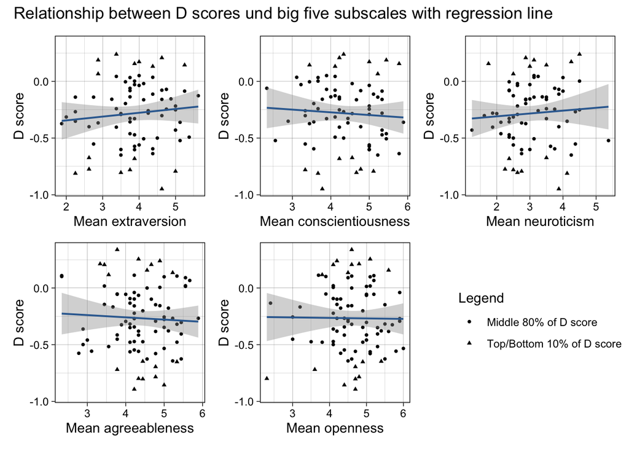

```r
combineplot_horizontal <-
  scatterplot_e + scatterplot_c +scatterplot_n + scatterplot_a + scatterplot_o +plot_annotation(
    title = 'Relationship between D scores und big five subscales with regression line')+
guide_area() +
  plot_layout(guides = 'collect')
combineplot_horizontal
```

```r
ggsave("../communications/combineplot.png",dpi = 300,combineplot_horizontal)
ggsave("../communications/combineplot.pdf",dpi = 300,combineplot_horizontal)
```